# Math189Pr_3

Overall Question: How do we find clusters of palindromes? How do we determine whether a cluster is just a chance occurrence or a potential replication site?

# Scenario 1: Random Scatter

# Import Dataset

```r
location <- read.table("hcmv-25kgjn1-1rfrtkc.txt", header = TRUE)
data <- read.csv("RAW_DATA-2iwcznn-2kr2xw0.csv", header = TRUE)
```

Generate structure that examine the locations of the palindromes. Simulate 296 palindrome sites chosen at random along a DNA sequence of 229,354 bases using a pseudo random number generator.

```r
set.seed(2017)
# Generate simple random sample
N <- 229354
n <- 296
uniform <- sample.int(N, size = n)
locations <- location$location
```

# Scenario 2: Locations

## Visulization of palindrome location distribution vs Uniform distribution

Using graphical methods to examine if the locations follow uniform distribution. The pink histogram and the red density curve represents distribution for actual data. The light blue histogram and the blue density curve represents the distribution and density for the simulated simple random sample. The purple histogram represents the overlapped area.

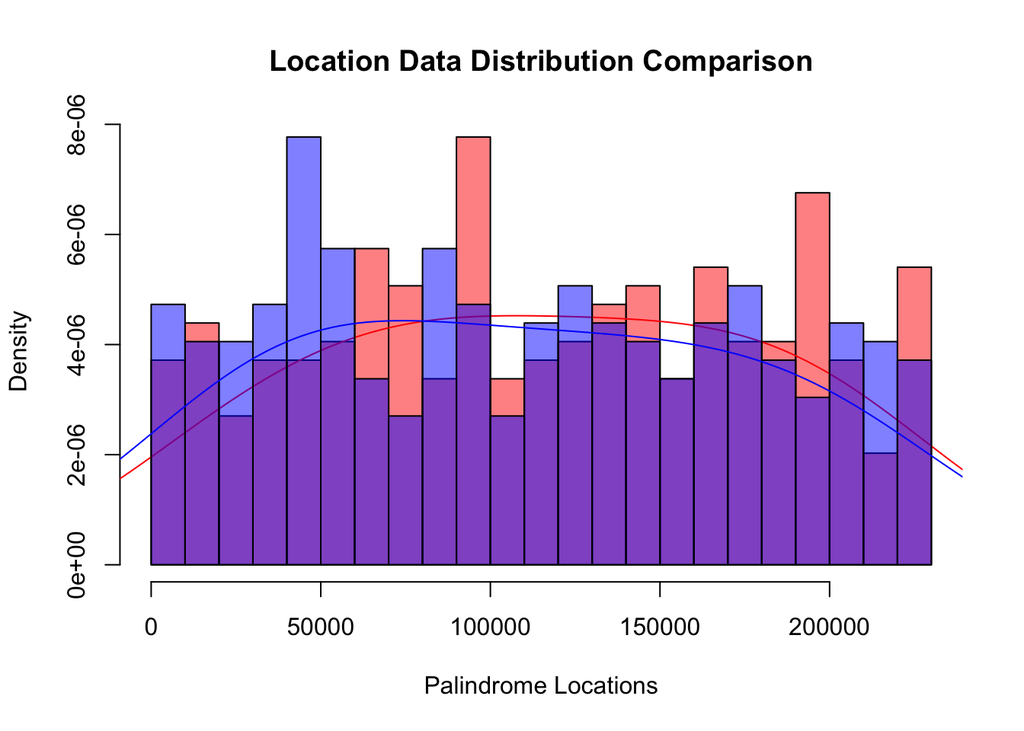

```r
hist(locations, breaks = 20, probability = TRUE, col = rgb(1,0,0,0.5), main = "Location Data Distribution Comparison", xlab= "Palindrome Locations")
lines(density(locations, adjust = 2), col = 2)
hist(uniform, breaks = 20, probability = TRUE, col = rgb(0,0,1,0.5), add = TRUE)
lines(density(uniform, adjust = 2), col = 4)
```

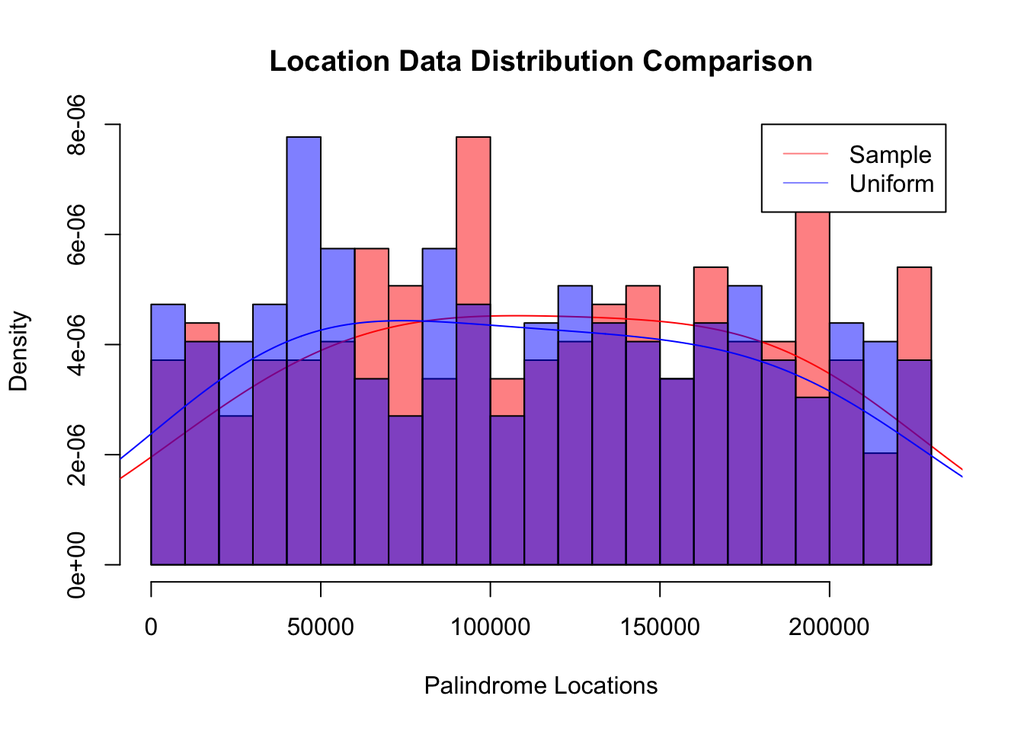

```r
pop <- location$location
hist(pop, breaks = 20, probability = TRUE, col = rgb(1,0,0,0.5), main = "Location Data Distribution Comparison", xlab= "Palindrome Locations")
lines(density(pop, adjust = 2), col = 2)
hist(uniform,breaks = 20, probability = TRUE, col = rgb(0,0,1,0.5), add = TRUE)
lines(density(uniform, adjust = 2), col = 4)
legend(x = 180000, y = 0.000008, legend = c("Sample", "Uniform"), lty = c(1,1), col = c(rgb(1,0,0,0.5), rgb(0,0,1,0.5)))
```

In Case 1, we group locations into 50 sub-intervals, and construct chi-square test statistic to compare it against the theoretical uniform distribution. ## Chi-square Goodness of Fit Test

```r
k <- 50
locations.expected <- n/k
tab <- table(cut(locations, breaks = seq(0, N, length.out = k+1), include.lowest = TRUE))
locations.observed <- as.vector(tab)
chi_2 <- sum((locations.observed - locations.expected)^2/locations.expected)
chi_2
```

```
## [1] 66.5
```

```r
chi2_compare <- qchisq(p = 0.95, df = 49)
chi2_compare
```

```
## [1] 66.33865
```

```r
p_value <- pchisq(chi_2, df = 49, lower.tail = FALSE)
p_value
```

```
## [1] 0.04864058
```

## Visualization of the Residual

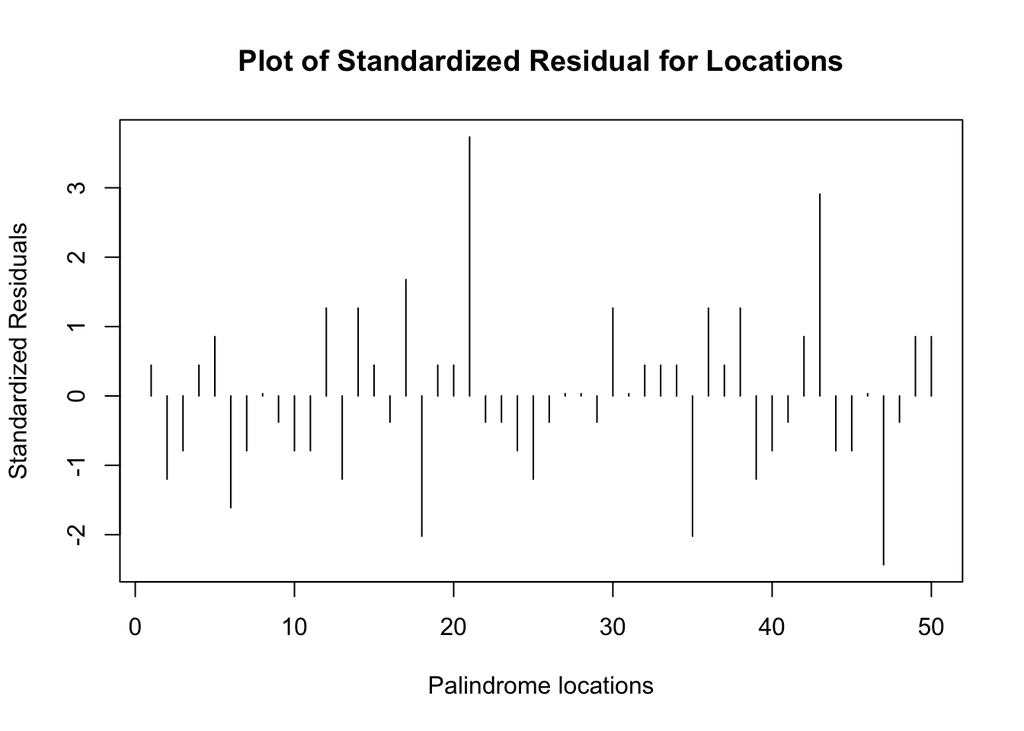

```r
Residuals <- (locations.observed - locations.expected) / sqrt(locations.expected)
plot(Residuals, type = 'h', ylab = "Standardized Residuals", xlab = "Palindrome locations", main = "Plot of Standardized Residual for Locations")
```

```r
k <- 100
locations.expected <- n/k
tab <- table(cut(locations, breaks = seq(0, N, length.out = k+1), include.lowest = TRUE))
locations.observed <- as.vector(tab)
chi_2 <- sum((locations.observed - locations.expected)^2/locations.expected)
chi_2
```

```
## [1] 141.1622
```

```r
chi2_compare <- qchisq(p = 0.95, df = 99)
chi2_compare
```

```
## [1] 123.2252
```

```r
p_value <- pchisq(chi_2, df = 99, lower.tail = FALSE)
p_value
```

```
## [1] 0.003479147
```

## Visualization of the Residual

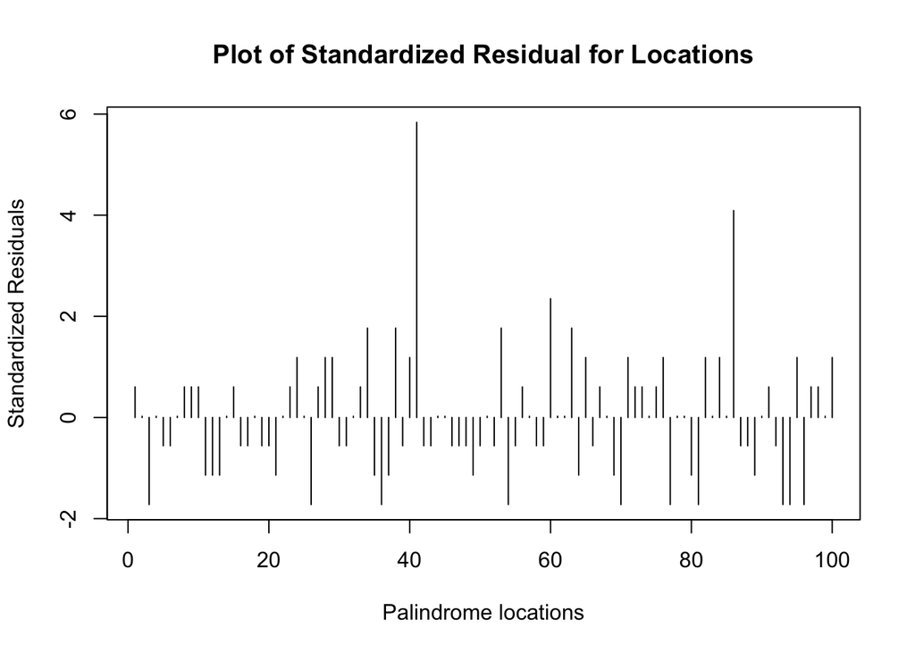

```r
Residuals <- (locations.observed - locations.expected) / sqrt(locations.expected)
plot(Residuals, type = 'h', ylab = "Standardized Residuals", xlab = "Palindrome locations", main = "Plot of Standardized Residual for Locations")
```

In case 3, we group locations into 500 sub-intervals, and construct chi-square test statistic to compare it against the theoretical uniform distribution. ## Chi-square Goodness of Fit Test

```r
k <- 500
locations.expected <- n/k
tab <- table(cut(locations, breaks = seq(0, N, length.out = k+1), include.lowest = TRUE))
locations.observed <- as.vector(tab)
chi_2 <- sum((locations.observed - locations.expected)^2/locations.expected)
chi_2
```

```
## [1] 633.0541
```

```r
chi2_compare <- qchisq(p = 0.95, df = 499)
chi2_compare
```

```
## [1] 552.0747
```

```r
p_value <- pchisq(chi_2, df = 499, lower.tail = FALSE)
p_value
```

```
## [1] 4.170577e-05
```

## Visualization of the Residual

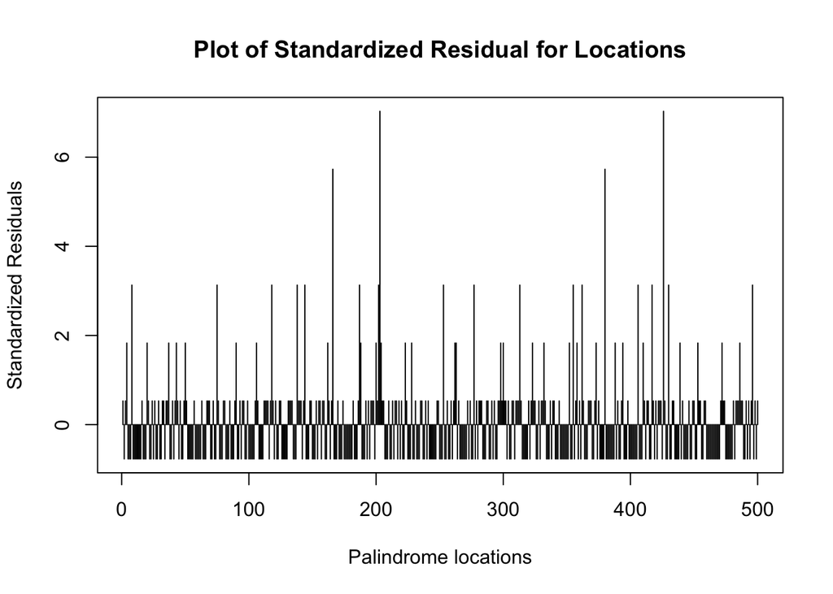

```r
Residuals <- (locations.observed - locations.expected) / sqrt(locations.expected)
plot(Residuals, type = 'h', ylab = "Standardized Residuals", xlab = "Palindrome locations", main = "Plot of Standardized Residual for Locations")
```

# Scenario 2: Spacings

# Visulization of palindrome spacings distribution

Using graphical methods to compare a generated Exponential sequence and the distribution of the palindromes counts in different sets of location intervals. Remark: The pink histogram and the red density curve represents the distribution and density for actual data. The light blue histogram and the blue density curve represents distribution for generated Exponential sequence. The purple histogram represents the overlapped area.

```r
pop.sorted = sort(pop, decreasing = FALSE)
distance.pair <- abs(pop.sorted[-1]-pop.sorted[-length(pop)])
distance.pair
```

```
##   [1] 1144  112   44 1771    7   31 3977 1760   61  249 1551  870 1109 1400
##  [15]  456 1294  412  327   60 1197 1167  149   90  615  802 1195  712  171
##  [29]  331 2708 2716 1713  612  513 1420 1180  295    5  320 1873  111 1919
##  [43] 1928  546  122 1154 1099  221 1492 2717  374   91  329 2471  291  782
##  [57]  386  810  239  334   25  105  933 1620  428 2945  306  178  889 1505
##  [71]   57   20  526  220  733 1053  234   13  213 1590  616 1512 1067  457
##  [85]  963  333 1500    6  482 1081  153   37   66  165   81 1518 2082 3309
##  [99] 2097  383   16  111  491    6 1580 1086  783  665  512  727  147  316
## [113]  573   44   73   58    8   38   36   76  251  140  261   90  573 1801
## [127] 1513 1005  415  801 1155 1275  129  443 1652  139 1032 1880  709 1062
## [141] 1039 3154  763 1486  167   24 1279 1458 1110   92  220  434   21  938
## [155] 3344  832 1269  209   22  541 1214  256  480 1663  534 1306 1181 1140
## [169]  690  354  173  292  510  213  102  416  969 1499  622  793  422  575
## [183]  261  297    6  183 2929  945  155  111  655  288 1235 1258  492  239
## [197]  177  109 2140  602  845 1699 3424  275 1366   21   12 1030  250   77
## [211]  999  812    8   40  441 1889  449  105 1530  643    1  618 2256  186
## [225]   83   53   75 3467  229  618 1551  249   61 1760 3977   31    7 1771
## [239]   44  112 1144  529 1108   67   11  302 1229  920  455  209  921   80
## [253]    5   34   70   41  573 1157   30  169 1004  514 2314   33 1142 2350
## [267]  955  497 1527  261  110  674 1304  593 5333  388  102  247  537 3473
## [281]  978  422  210  414  246  182  543 1450  818 1124  302   11   67 1108
## [295]  529
```

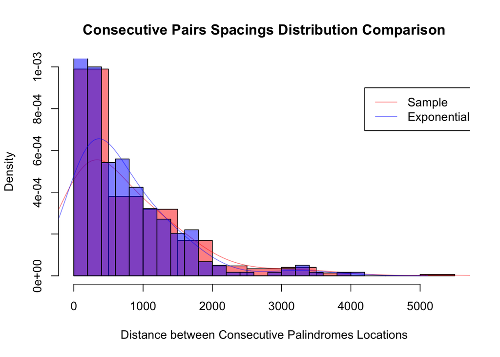

```r
hist(distance.pair, breaks= 15, col = rgb(1,0,0,0.5), probability = TRUE, main = "Consecutive Pairs Spacings Distribution Comparison", xlab = "Distance between Consecutive Palindromes Locations", ylim = c(0,0.001))
lines(density(distance.pair, adjust = 2), col = rgb(1,0,0,0.5))
Expo <- rexp(n-1, rate = 1/mean(distance.pair))
hist(Expo, breaks = 15, col = rgb(0,0,1,0.5), probability = TRUE, add = TRUE)
lines(density(Expo, adjust = 2), col = rgb(0,0,1,0.5))
legend(x = 4200, y = 0.0009, legend = c("Sample", "Exponential"), lty = c(1,1), col = c(rgb(1,0,0,0.5), rgb(0,0,1,0.5)))
```